# TUGAS 2 TUTORIAL ONLINE

## KALKULUS DIFERENSIAL

- NAMA : RIZIQ LILI ULIL ALBAB
- NIM : 058487469

TOOLS yang digunakan untuk menyelesaikan tugas ini adalah:

- Jupyter Notebook
- Python
- Wolfram Alpha
- Latex

Untuk Link notebook ini bisa diakses di [sini](https://github.com/riziqalbab/Statistics_UT/blob/main/STMA4111%20KALKULUS%20DIFERENSIAL/SESI%205/tugas2.ipynb)

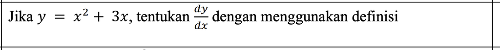

Diketahui:

$$ y = x^2 + 3x $$

Dengan definisi turunan:

$$ \frac{dy}{dx} = \lim_{h \to 0} \frac{f(x+h)-f(x)}{h} $$

Misalkan:

$$ f(x) = x^2 + 3x $$

Maka:

$$ f(x+h) = (x+h)^2 + 3(x+h) $$

$$ = x^2 + 2xh + h^2 + 3x + 3h $$

Sehingga:

$$ \frac{dy}{dx} = \lim_{h \to 0} \frac{(x^2 + 2xh + h^2 + 3x + 3h) - (x^2 + 3x)}{h} $$

$$ = \lim_{h \to 0} \frac{2xh + h^2 + 3h}{h} $$

$$ = \lim_{h \to 0} (2x + h + 3) $$

$$ = 2x + 3 $$

Jadi:

$$ \frac{dy}{dx} = 2x + 3 $$

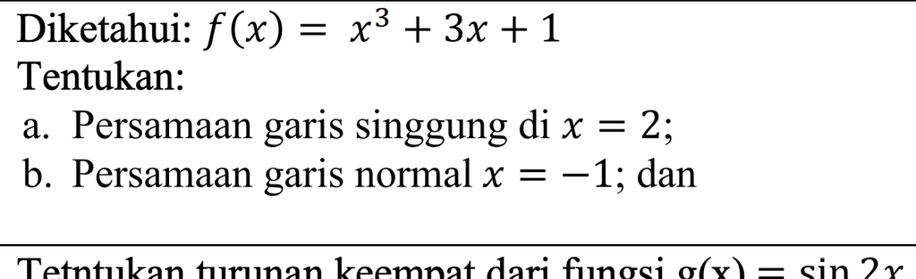

Diketahui:

$$ f(x) = x^3 + 3x + 1 $$

Turunan pertama:

$$ f'(x) = 3x^2 + 3 $$

### a. Persamaan garis singgung di (x = 2)

Nilai fungsi saat (x = 2):

$$ f(2) = 2^3 + 3(2) + 1 $$

$$ f(2) = 8 + 6 + 1 = 15 $$

Jadi titiknya adalah:

$$ (2, 15) $$

Gradien garis singgung:

$$ m = f'(2) $$

$$ m = 3(2)^2 + 3 $$

$$ m = 12 + 3 = 15 $$

Persamaan garis singgung:

$$ y - y_1 = m(x - x_1) $$

$$ y - 15 = 15(x - 2) $$

$$ y - 15 = 15x - 30 $$

$$ y = 15x - 15 $$

Jadi, persamaan garis singgungnya adalah:

$$ \boxed{y = 15x - 15} $$

### b. Persamaan garis normal di (x = -1)

Nilai fungsi saat (x = -1):

$$ f(-1) = (-1)^3 + 3(-1) + 1 $$

$$ f(-1) = -1 - 3 + 1 = -3 $$

Jadi titiknya adalah:

$$ (-1, -3) $$

Gradien garis singgung:

$$ m_s = f'(-1) $$

$$ m_s = 3(-1)^2 + 3 $$

$$ m_s = 3 + 3 = 6 $$

Gradien garis normal:

$$ m_n = -\frac{1}{m_s} $$

$$ m_n = -\frac{1}{6} $$

Persamaan garis normal:

$$ y - y_1 = m(x - x_1) $$

$$ y - (-3) = -\frac{1}{6}(x - (-1)) $$

$$ y + 3 = -\frac{1}{6}(x + 1) $$

$$ y + 3 = -\frac{1}{6}x - \frac{1}{6} $$

$$ y = -\frac{1}{6}x - \frac{19}{6} $$

Jadi, persamaan garis normalnya adalah:

$$ y = -\frac{1}{6}x - \frac{19}{6} $$

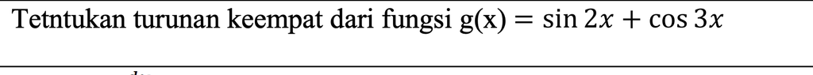

Diketahui:

$$ g(x) = \sin 2x + \cos 3x $$

Tentukan turunan keempat.

Turunan pertama:

$$ g'(x) = 2\cos 2x - 3\sin 3x $$

Turunan kedua:

$$ g''(x) = -4\sin 2x - 9\cos 3x $$

Turunan ketiga:

$$ g'''(x) = -8\cos 2x + 27\sin 3x $$

Turunan keempat:

$$ g^{(4)}(x) = 16\sin 2x + 81\cos 3x $$

Jadi, turunan keempat dari fungsi tersebut adalah:

$$ \boxed{g^{(4)}(x) = 16\sin 2x + 81\cos 3x} $$

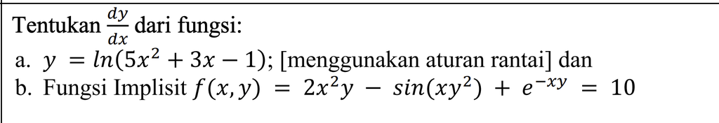

Diketahui:

$$ y = \ln(5x^2 + 3x - 1) $$

Gunakan aturan rantai:

$$ \frac{d}{dx}[\ln u] = \frac{u'}{u} $$

Misalkan:

$$ u = 5x^2 + 3x - 1 $$

Maka:

$$ u' = 10x + 3 $$

Sehingga:

$$ \frac{dy}{dx} = \frac{10x + 3}{5x^2 + 3x - 1} $$

Jadi:

$$ \boxed{\frac{dy}{dx} = \frac{10x + 3}{5x^2 + 3x - 1}} $$

Diketahui fungsi implisit:

$$ 2x^2y - \sin(xy^2) + e^{-xy} = 10 $$

Turunkan kedua ruas terhadap (x):

$$ \frac{d}{dx}(2x^2y) - \frac{d}{dx}[\sin(xy^2)] + \frac{d}{dx}(e^{-xy}) = \frac{d}{dx}(10) $$

Untuk suku pertama:

$$ \frac{d}{dx}(2x^2y) = 4xy + 2x^2\frac{dy}{dx} $$

Untuk suku kedua:

$$ \frac{d}{dx}[\sin(xy^2)] = \cos(xy^2)\left(y^2 + 2xy\frac{dy}{dx}\right) $$

Untuk suku ketiga:

$$ \frac{d}{dx}(e^{-xy}) = e^{-xy}\left(-y - x\frac{dy}{dx}\right) $$

Maka:

$$ 4xy + 2x^2\frac{dy}{dx} - \cos(xy^2)\left(y^2 + 2xy\frac{dy}{dx}\right) + e^{-xy}\left(-y - x\frac{dy}{dx}\right) = 0 $$

Kelompokkan:

$$ 2x^2\frac{dy}{dx} - 2xy\cos(xy^2)\frac{dy}{dx} - xe^{-xy}\frac{dy}{dx} + 4xy - y^2\cos(xy^2) - ye^{-xy} = 0 $$

Pindahkan suku:

$$ \left(2x^2 - 2xy\cos(xy^2) - xe^{-xy}\right)\frac{dy}{dx} = -4xy + y^2\cos(xy^2) + ye^{-xy} $$

Jadi:

$$ \frac{dy}{dx} = \frac{-4xy + y^2\cos(xy^2) + ye^{-xy}} {2x^2 - 2xy\cos(xy^2) - xe^{-xy}} $$

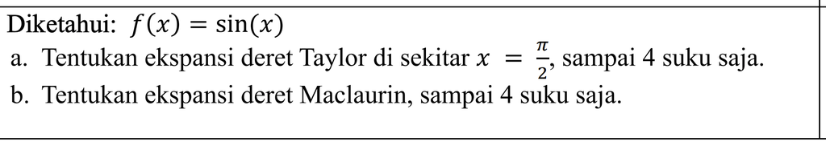

Diketahui:

$$ f(x) = \sin(x) $$

## a. Ekspansi deret Taylor di sekitar sampai 4 suku

Rumus deret Taylor:

$$ f(x) = f(a) + f'(a)(x-a) + \frac{f''(a)}{2!}(x-a)^2 + \frac{f'''(a)}{3!}(x-a)^3 + \cdots $$

Dengan:

$$ a = \frac{\pi}{2} $$

Turunan fungsi:

$$ f(x) = \sin x $$

$$ f'(x) = \cos x $$

$$ f''(x) = -\sin x $$

$$ f'''(x) = -\cos x $$

$$ f^{(4)}(x) = \sin x $$

$$ f\left(\frac{\pi}{2}\right) = 1 $$

$$ f'\left(\frac{\pi}{2}\right) = 0 $$

$$ f''\left(\frac{\pi}{2}\right) = -1 $$

$$ f'''\left(\frac{\pi}{2}\right) = 0 $$

$$ f^{(4)}\left(\frac{\pi}{2}\right) = 1 $$

Maka deret Taylor-nya:

$$ \sin x = 1 - \frac{\left(x-\frac{\pi}{2}\right)^2}{2!} + \frac{\left(x-\frac{\pi}{2}\right)^4}{4!} - \frac{\left(x-\frac{\pi}{2}\right)^6}{6!} + \cdots $$

Sampai 4 suku:

$$ \boxed{ \sin x = 1 - \frac{\left(x-\frac{\pi}{2}\right)^2}{2!} + \frac{\left(x-\frac{\pi}{2}\right)^4}{4!} - \frac{\left(x-\frac{\pi}{2}\right)^6}{6!} } $$

## b. Ekspansi deret Maclaurin sampai 4 suku

Deret Maclaurin adalah deret Taylor di sekitar:

$$ x = 0 $$

Untuk fungsi:

$$ f(x) = \sin x $$

Deret Maclaurin-nya adalah:

$$ \sin x = x - \frac{x^3}{3!} + \frac{x^5}{5!} - \frac{x^7}{7!} + \cdots $$

Sampai 4 suku:

$$ \boxed{ \sin x = x - \frac{x^3}{3!} + \frac{x^5}{5!} - \frac{x^7}{7!} } $$